# Descriptive Analysis of London bikes hires w.r.t covid resrictions

Nazish Khan

# Loading the required libraries

```r
knitr::opts_chunk$set()
library(dplyr)
library(ggplot2)
library(knitr) # for table()
library(Rmisc) # for CI()
library(emmeans) # for emmeans() and pairs()
library(gridExtra) # for grid.arrange()
library(Hmisc)
library(car)
library(tidyverse)
library(kableExtra)
options(width=100)
```

# Topic: London Bike Hires and Covid Restrictions

## Data Dictionary

This section will showcase bikes hires analysis past covid-19 and impact of several features such as work from home, eat out to help out, etc. policies. on the dependent variable i.e. Hires. The data dictionary used for this analysis includes information about each variable, such as its variable name, description, and data type.

| Variable | Description | Data Type |
| --- | --- | --- |
| date | Date of data entry | Date |
| Hires | Number of hires recorded on the corresponding date | Numeric |
| schools_closed | Binary variable indicating whether schools are closed (0 for ‘no’, 1 for ‘yes’) | Numeric |
| pubs_closed | Binary variable indicating whether pubs are closed (0 for ‘no’, 1 for ‘yes’) | Numeric |
| shops_closed | Binary variable indicating whether shops are closed (0 for ‘no’, 1 for ‘yes’) | Numeric |
| eating_places_closed | Binary variable indicating whether eating places are closed (0 for ‘no’, 1 for ‘yes’) | Numeric |
| stay_at_home | Binary variable indicating whether there is a stay-at-home order (0 for ‘no’, 1 for ‘yes’) | Numeric |
| household_mixing_indoors_banned | Binary variable indicating whether household mixing indoors is banned (0 for ‘no’, 1 for ‘yes’) | Numeric |
| wfh | Binary variable indicating whether there is a work-from-home policy (0 for ‘no’, 1 for ‘yes’) | Factor |
| rule_of_6_indoors | Binary variable indicating whether the rule of 6 indoors is in effect (0 for ‘no’, 1 for ‘yes’) | Factor |
| curfew | Binary variable indicating whether there is a curfew (0 for ‘no’, 1 for ‘yes’) | Numeric |
| eat_out_to_help_out | Binary variable indicating whether there is an “Eat Out to Help Out” policy (0 for ‘no’, 1 for ‘yes’) | Factor |
| day | Day of the week | Character |
| month | Month of the year | Character |
| year | Year of data collection | Numeric |

## Data Load

```r
# Load the CSV file in the bikes dataframe
bikes <- read.csv("London_COVID_bikes.csv")
head(bikes,10)
```

```
##          date Hires schools_closed pubs_closed shops_closed eating_places_closed stay_at_home
## 1  2010-07-30  6897              0           0            0                    0            0
## 2  2010-07-31  5564              0           0            0                    0            0
## 3  2010-08-01  4303              0           0            0                    0            0
## 4  2010-08-02  6642              0           0            0                    0            0
## 5  2010-08-03  7966              0           0            0                    0            0
## 6  2010-08-04  7893              0           0            0                    0            0
## 7  2010-08-05  8724              0           0            0                    0            0
## 8  2010-08-06  9797              0           0            0                    0            0
## 9  2010-08-07  6631              0           0            0                    0            0
## 10 2010-08-08  7864              0           0            0                    0            0
##    household_mixing_indoors_banned wfh rule_of_6_indoors curfew eat_out_to_help_out day month year
## 1                                0   0                 0      0                   0 Fri   Jul 2010
## 2                                0   0                 0      0                   0 Sat   Jul 2010
## 3                                0   0                 0      0                   0 Sun   Aug 2010
## 4                                0   0                 0      0                   0 Mon   Aug 2010
## 5                                0   0                 0      0                   0 Tue   Aug 2010
## 6                                0   0                 0      0                   0 Wed   Aug 2010
## 7                                0   0                 0      0                   0 Thu   Aug 2010
## 8                                0   0                 0      0                   0 Fri   Aug 2010
## 9                                0   0                 0      0                   0 Sat   Aug 2010
## 10                               0   0                 0      0                   0 Sun   Aug 2010
```

The dataset includes information on the number of hires and the status of closures, restrictions, and policies on specific dates. Key columns and their meanings are:

date: Represents the date. Hires: Indicates the number of hires on each corresponding date. schools_closed, pubs_closed, shops_closed, eating_places_closed, stay_at_home, household_mixing_indoors_banned, wfh, rule_of_6_indoors, curfew, eat_out_to_help_out: Binary indicators (0 or 1) for the closure status of various entities and policy implementations. day: Represents the day of the week. month: Represents the month. year: Represents the year.

This dataset provides insights into the interplay between restrictions, policies, and events on specific dates and the corresponding number of hires. It appears suitable for investigating how these factors may influence hiring patterns over time.

## Data Understanding

Let’s check the structure and summary of the dataframe.

```r
#Structure of the data
str(bikes)
```

```
## 'data.frame':    4812 obs. of  15 variables:
##  $ date                           : chr  "2010-07-30" "2010-07-31" "2010-08-01" "2010-08-02" ...
##  $ Hires                          : int  6897 5564 4303 6642 7966 7893 8724 9797 6631 7864 ...
##  $ schools_closed                 : int  0 0 0 0 0 0 0 0 0 0 ...
##  $ pubs_closed                    : int  0 0 0 0 0 0 0 0 0 0 ...
##  $ shops_closed                   : int  0 0 0 0 0 0 0 0 0 0 ...
##  $ eating_places_closed           : int  0 0 0 0 0 0 0 0 0 0 ...
##  $ stay_at_home                   : int  0 0 0 0 0 0 0 0 0 0 ...
##  $ household_mixing_indoors_banned: int  0 0 0 0 0 0 0 0 0 0 ...
##  $ wfh                            : int  0 0 0 0 0 0 0 0 0 0 ...
##  $ rule_of_6_indoors              : int  0 0 0 0 0 0 0 0 0 0 ...
##  $ curfew                         : int  0 0 0 0 0 0 0 0 0 0 ...
##  $ eat_out_to_help_out            : int  0 0 0 0 0 0 0 0 0 0 ...
##  $ day                            : chr  "Fri" "Sat" "Sun" "Mon" ...
##  $ month                          : chr  "Jul" "Jul" "Aug" "Aug" ...
##  $ year                           : int  2010 2010 2010 2010 2010 2010 2010 2010 2010 2010 ...
```

```r
#Summary of data
summary(bikes)
```

```
##      date               Hires       schools_closed     pubs_closed       shops_closed
##  Length:4812        Min.   :    0   Min.   :0.00000   Min.   :0.00000   Min.   :0.00000
##  Class :character   1st Qu.:19776   1st Qu.:0.00000   1st Qu.:0.00000   1st Qu.:0.00000
##  Mode  :character   Median :26356   Median :0.00000   Median :0.00000   Median :0.00000
##                     Mean   :26607   Mean   :0.02743   Mean   :0.05175   Mean   :0.04634
##                     3rd Qu.:33481   3rd Qu.:0.00000   3rd Qu.:0.00000   3rd Qu.:0.00000
##                     Max.   :73094   Max.   :1.00000   Max.   :1.00000   Max.   :1.00000
##  eating_places_closed  stay_at_home     household_mixing_indoors_banned      wfh
##  Min.   :0.00000      Min.   :0.00000   Min.   :0.00000                 Min.   :0.0000
##  1st Qu.:0.00000      1st Qu.:0.00000   1st Qu.:0.00000                 1st Qu.:0.0000
##  Median :0.00000      Median :0.00000   Median :0.00000                 Median :0.0000
##  Mean   :0.05175      Mean   :0.03616   Mean   :0.06525                 Mean   :0.2273
##  3rd Qu.:0.00000      3rd Qu.:0.00000   3rd Qu.:0.00000                 3rd Qu.:0.0000
##  Max.   :1.00000      Max.   :1.00000   Max.   :1.00000                 Max.   :1.0000
##  rule_of_6_indoors     curfew        eat_out_to_help_out     day               month
##  Min.   :0.00000   Min.   :0.00000   Min.   :0.000000    Length:4812        Length:4812
##  1st Qu.:0.00000   1st Qu.:0.00000   1st Qu.:0.000000    Class :character   Class :character
##  Median :0.00000   Median :0.00000   Median :0.000000    Mode  :character   Mode  :character
##  Mean   :0.01995   Mean   :0.01164   Mean   :0.005819
##  3rd Qu.:0.00000   3rd Qu.:0.00000   3rd Qu.:0.000000
##  Max.   :1.00000   Max.   :1.00000   Max.   :1.000000
##       year
##  Min.   :2010
##  1st Qu.:2013
##  Median :2017
##  Mean   :2017
##  3rd Qu.:2020
##  Max.   :2023
```

## Data Preparation

As we are interested in the effect upon bike hire usage as a result of three elements of the COVID response: Work From Home, Rule of 6 Indoors, and the Eat Out to Help Out scheme. Also we will explore whether it is appropriate to control for the effect of potential differences between different years, months, and days of the week.

So, there are few steps to be follwed: 1. Changing the datatype to factor of the character variables 2. Remove unused columns from the dataframe

```r
#change the datatypes to factor
bikes$wfh <- factor(bikes$wfh)
bikes$rule_of_6_indoors <- factor(bikes$rule_of_6_indoors)
bikes$eat_out_to_help_out <- factor(bikes$eat_out_to_help_out)
bikes$day <- as.factor(bikes$day)
bikes$month <- as.factor(bikes$month)


#Unused Columns to remove
columns_to_remove <- c("schools_closed", "pubs_closed", "shops_closed","eating_places_closed","stay_at_home","household_mixing_indoors_banned","curfew")

bikes <- bikes[, -which(names(bikes) %in% columns_to_remove)]


#Sort data with date
sorted_data <- bikes %>% arrange(date)
```

## Data Integrity and Outliers Handling

Checking the data distribution for number of bikes hired and handling the outliers to enhance dataset reliability for subsequent analyses.

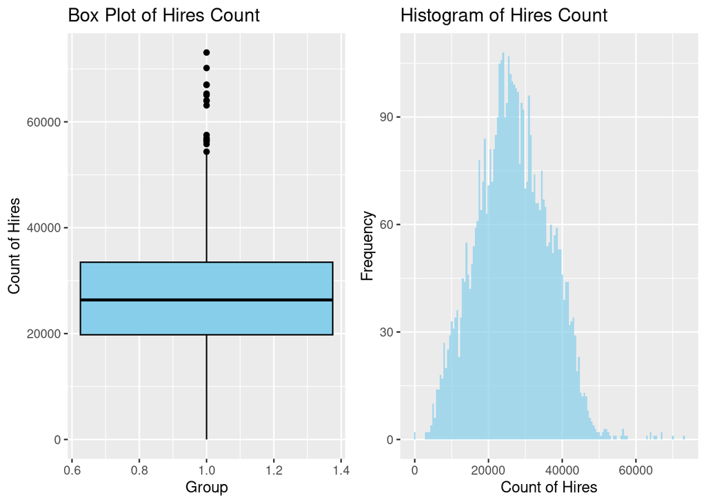

```r
#Checking the integrity of the data
bikes <- na.omit(bikes)

#Checking for the outliers
#Create a box plot for the count of hires
plot1 <- ggplot(bikes, aes(x = 1, y = Hires)) +
  geom_boxplot(fill = "skyblue", color = "black") +
  labs(title = "Box Plot of Hires Count",
       x = "Group",  # Remove x-axis label
       y = "Count of Hires")

# Create a histogram for the count of hires
plot2 <- ggplot(bikes, aes(x = Hires)) +
  geom_histogram(binwidth = 500, fill = "skyblue", alpha = 0.7) +
  labs(title = "Histogram of Hires Count",
       x = "Count of Hires",
       y = "Frequency")
grid.arrange(plot1, plot2, ncol=2)
```

```r
# Removing outliers where hires is greater than 60000 and less equal to zero
bikes <- bikes[!(bikes$Hires > 60000 | bikes$Hires <= 0), ]
str(bikes$Hires)
```

```
##  int [1:4801] 6897 5564 4303 6642 7966 7893 8724 9797 6631 7864 ...
```

The dataset does not have any NA values. While the data cleaning process, outtliers were identified and removed. We have removed 11 outliers from the dataset where the number of hires exceeded 60,000 or was less than or equal to 0.

## Data Visualisation

Identifying Data Pattern & Data Distribution

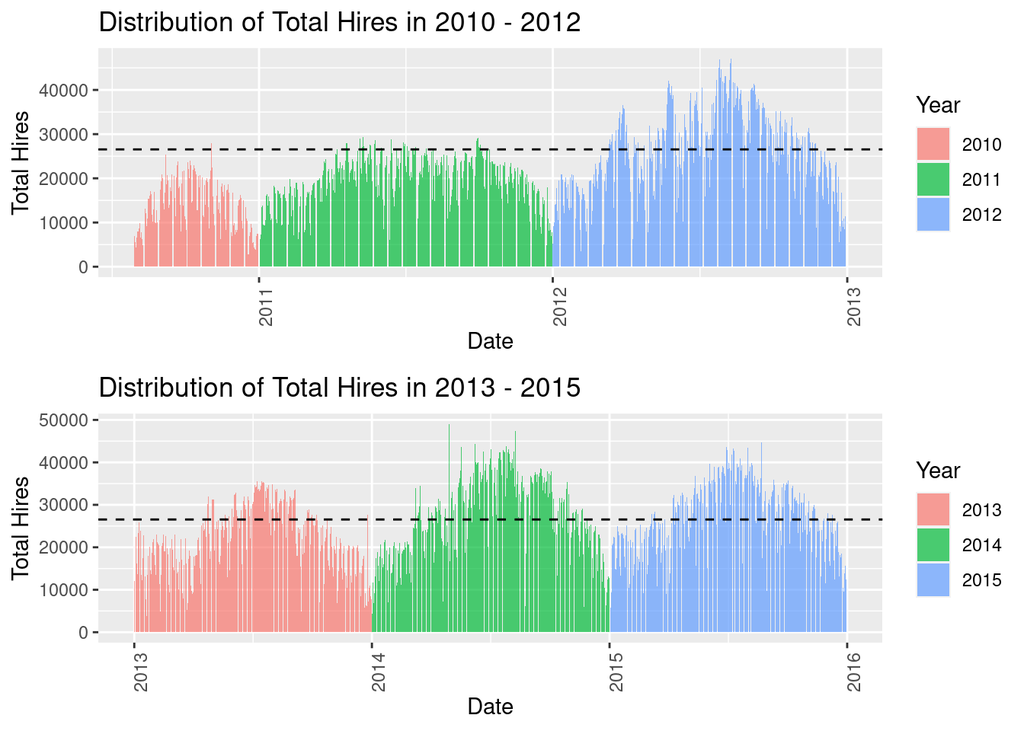

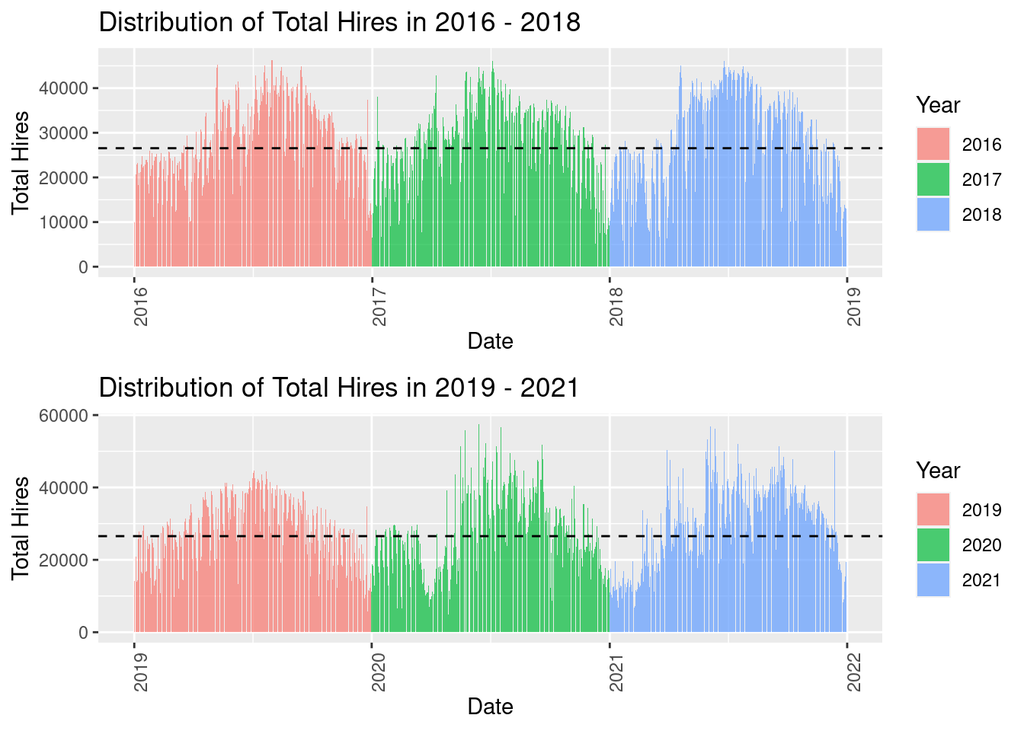

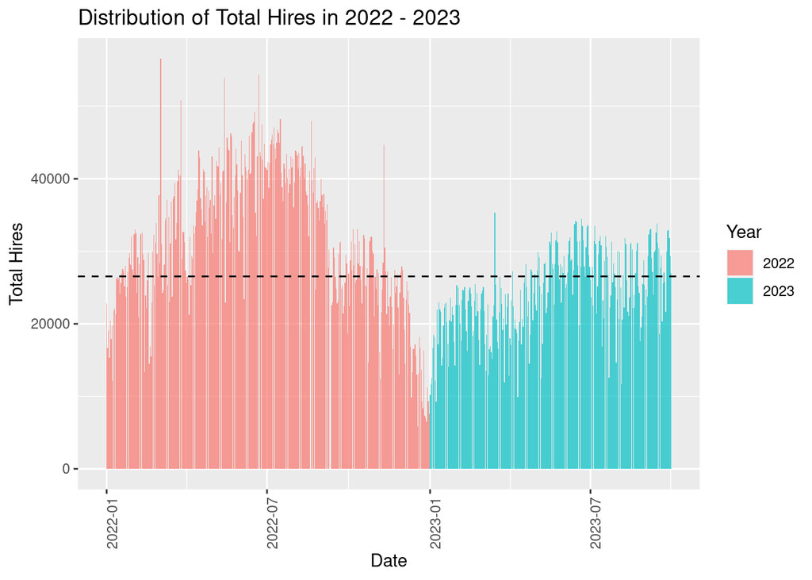

```r
#Hires trend chart for the year 2010
# Assuming the "date" column is in Date format
bikes$date <- as.Date(bikes$date)

#str(bikes)

# Define a function to create the plot for a specific year
yearly_plot <- function(start_year, end_year) {
  # Filter data for the specified date range
  filtered_data <- bikes %>% filter(year >= start_year & year <= end_year)

  # Create a histogram
  plot_year <- ggplot(filtered_data, aes(x = date, y = Hires, fill = factor(year))) +
    geom_histogram(stat = "identity", position = "stack", alpha = 0.7, binwidth = 30) +
    geom_hline(yintercept = mean(bikes$Hires), color = "black", linetype = "dashed") +
    theme(axis.text.x = element_text(angle = 90, hjust = 1))+
    labs(title = paste("Distribution of Total Hires in", start_year, "-", end_year),
         x = "Date",
         y = "Total Hires",
         fill = "Year")

  return(plot_year)
}

# Create individual plots for each year
plot_1012 <- yearly_plot(2010, 2012)
plot_1315 <- yearly_plot(2013, 2015)
plot_1618 <- yearly_plot(2016, 2018)
plot_1921 <- yearly_plot(2019, 2021)
plot_2223 <- yearly_plot(2022, 2023)
```

To check the pattern in the hires distribution, see the following graph depicting the trend:

[figure not shown]

```r
# Define a function to create the plot for a specific month
monthly_plot <- function(year_var) {
  # Filter data for the specified date range
  filtered_data1 <- bikes %>% filter(year == year_var)

  # Create a histogram
  plot_month <- ggplot(filtered_data1, aes(x = factor(month, levels = c("Jan", "Feb", "Mar", "Apr", "May", "Jun", "Jul", "Aug", "Sep", "Oct", "Nov", "Dec")), y = Hires)) +
    geom_histogram(stat = "identity", position = "stack", alpha = 0.7, binwidth = 15, fill="skyblue")+
    theme(axis.text.x = element_text(angle = 90, hjust = 1))+
    scale_fill_discrete(breaks = c("Jan", "Feb", "Mar", "Apr", "May", "Jun", "Jul", "Aug", "Sep", "Oct", "Nov", "Dec"))+
    labs(title = paste(year_var, "Distribution"),
         x = "Month",
         y = "Total Hires",
         fill = "Year")

  return(plot_month)
}

# Create individual plots for each year
plot_2016 <- monthly_plot(2016)
plot_2017 <- monthly_plot(2017)
plot_2018 <- monthly_plot(2018)
plot_2019 <- monthly_plot(2019)
plot_2020 <- monthly_plot(2020)
plot_2021 <- monthly_plot(2021)
plot_2022 <- monthly_plot(2022)
plot_2023 <- monthly_plot(2023)
```

The annual pattern of total bike hires exhibits a consistent trend, typically rising from January to April and experiencing a notable surge from April to July-August. Subsequently, there is a gradual decline in hires from August to December. However, the year 2020 witnessed a significant deviation from this pattern due to the COVID-19 pandemic.

## Distribution of WFH, Rule of 6 indoor, & eat out to help out policies over Bike Rentals

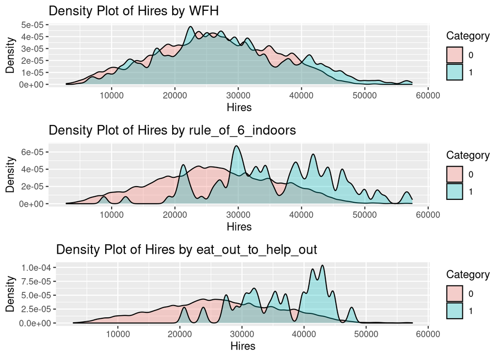

```r
# Assuming 'bikes' is your data frame
grid.arrange(
ggplot(bikes, aes(x = Hires)) +
  geom_density(aes(fill = factor(wfh)), alpha = 0.3, color = "black", bw = 500) +
  labs(title = "Density Plot of Hires by WFH",
       x = "Hires",
       y = "Density",
       fill = "Category"),

ggplot(bikes, aes(x = Hires)) +
  geom_density(aes(fill = factor(rule_of_6_indoors)), alpha = 0.3, color = "black", bw = 500) +
  labs(title = "Density Plot of Hires by rule_of_6_indoors",
       x = "Hires",
       y = "Density",
       fill = "Category"),

ggplot(bikes, aes(x = Hires)) +
  geom_density(aes(fill = factor(eat_out_to_help_out)), alpha = 0.3, color = "black", bw = 500) +
  labs(title = "Density Plot of Hires by eat_out_to_help_out",
       x = "Hires",
       y = "Density",
       fill = "Category"))
```

```r
#Let's perform estimation on the Hires bikes data
mean_estimate <- mean(bikes$Hires)
median_estimate <- median(bikes$Hires)
sd_estimate <- sd(bikes$Hires)
print(mean_estimate)
```

```
## [1] 26543.59
```

```r
print(median_estimate)
```

```
## [1] 26345
```

```r
print(sd_estimate)
```

```
## [1] 9535.375
```

## Correlation

Let’s find out the correlation between the different variables first

```r
#Correlation
rcorr(as.matrix(select(bikes, Hires, wfh, rule_of_6_indoors, eat_out_to_help_out,year)), type = "pearson")
```

```
##                     Hires   wfh rule_of_6_indoors eat_out_to_help_out year
## Hires                1.00  0.07              0.14                0.08 0.28
## wfh                  0.07  1.00              0.24               -0.04 0.70
## rule_of_6_indoors    0.14  0.24              1.00               -0.01 0.15
## eat_out_to_help_out  0.08 -0.04             -0.01                1.00 0.07
## year                 0.28  0.70              0.15                0.07 1.00
##
## n= 4801
##
##
## P
##                     Hires  wfh    rule_of_6_indoors eat_out_to_help_out year
## Hires                      0.0000 0.0000            0.0000              0.0000
## wfh                 0.0000        0.0000            0.0041              0.0000
## rule_of_6_indoors   0.0000 0.0000                   0.4485              0.0000
## eat_out_to_help_out 0.0000 0.0041 0.4485                                0.0000
## year                0.0000 0.0000 0.0000            0.0000
```

**Correlation Matrix:**

*Hires and WFH*: Weak positive relationship (0.07). *Hires and Rule_of_6_Indoors*: Weak positive relationship (0.14). *Hires and Eat_Out_to_Help_Out*: Weak positive relationship (0.08). *Hires and Year*: Moderate positive relationship (0.28). *WFH and Rule_of_6_Indoors*: Weak positive relationship (0.24). *WFH and Eat_Out_to_Help_Out*: Very weak negative relationship (-0.04). *Rule_of_6_Indoors and Eat_Out_to_Help_Out*: Very weak negative relationship (-0.01). *Year and WFH*: Strong positive relationship (0.70).

## Part 1

Analysis of WFH, Rule of 6 indoors, and eat out to help out scheme

### T-test and Linear Model Analysis

#### Work from Home Impact Analysis on Hires

```r
# Two-sample t-test for each variable with respect to 'Hires'
ttest_wfh <- t.test(Hires ~ wfh, data = bikes)
print(ttest_wfh)
```

```
##
##  Welch Two Sample t-test
##
## data:  Hires by wfh
## t = -4.6446, df = 1653.1, p-value = 3.677e-06
## alternative hypothesis: true difference in means between group 0 and group 1 is not equal to 0
## 95 percent confidence interval:
##  -2273.3227  -923.3737
## sample estimates:
## mean in group 0 mean in group 1
##        26182.37        27780.72
```

```r
#LM
m_wfh <- lm(Hires ~ wfh, data = bikes)
summary(m_wfh)
```

```
##
## Call:
## lm(formula = Hires ~ wfh, data = bikes)
##
## Residuals:
##      Min       1Q   Median       3Q      Max
## -23418.4  -6761.4   -226.4   6866.3  29735.3
##
## Coefficients:
##             Estimate Std. Error t value Pr(>|t|)
## (Intercept)  26182.4      156.1 167.778  < 2e-16 ***
## wfh1          1598.3      328.3   4.869 1.16e-06 ***
## ---
## Signif. codes:  0 '***' 0.001 '**' 0.01 '*' 0.05 '.' 0.1 ' ' 1
##
## Residual standard error: 9513 on 4799 degrees of freedom
## Multiple R-squared:  0.004916,   Adjusted R-squared:  0.004709
## F-statistic: 23.71 on 1 and 4799 DF,  p-value: 1.157e-06
```

```r
( m_wfh.emm <- emmeans(m_wfh, ~ wfh) )
```

```
##  wfh emmean  SE   df lower.CL upper.CL
##  0    26182 156 4799    25876    26488
##  1    27781 289 4799    27215    28347
##
## Confidence level used: 0.95
```

**NHST approach:** A Welch Two Sample t-test reveals a significant difference in means between group 0 and group 1 (t = -4.6446, df = 1653.1, p = 3.677e-06). The p-value (3.677e-06) is less than 0.05, suggesting a significant difference. The 95% confidence interval for the true difference in means is [-2273.3227, -923.3737]. The mean number of hires in group 0 is 26,182.37, and in group 1 is 27,780.72.

**Estimation approach:** The true difference in means between group 0 and group 1 is likely to fall within the 95% confidence interval of [-2273.3227, -923.3737]. Mean hires in group 0 is 26,182.37, and in group 1 is 27,780.72. These results indicate a statistically significant difference in mean hires between the two groups, with group 1 having a higher mean than group 0.

**This linear regression model suggests:**

Effect of Working from Home (WFH): For each unit increase in WFH (going from 0 to 1), there’s an estimated increase of 1,598.3 hires. The model is statistically significant (p < 0.001).

Prediction: When WFH is 0, estimated hires range from 25,876 to 26,488. When WFH is 1, estimated hires range from 27,215 to 28,347.

Overall Model Significance: The model as a whole is statistically significant (F-statistic: 23.71, p-value: 1.157e-06).

Model Fit: The model explains a limited portion of the variation in hires (R-squared: 0.0049).

#### Rule of 6 Indoors Scheme Impact Analysis on Hires

```r
ttest_rule <- t.test(Hires ~ rule_of_6_indoors, data = bikes)
print(ttest_rule)
```

```
##
##  Welch Two Sample t-test
##
## data:  Hires by rule_of_6_indoors
## t = -9.3856, df = 98.712, p-value = 2.455e-15
## alternative hypothesis: true difference in means between group 0 and group 1 is not equal to 0
## 95 percent confidence interval:
##  -11357.219  -7393.075
## sample estimates:
## mean in group 0 mean in group 1
##        26356.12        35731.27
```

```r
m_rule6 <- lm(Hires ~ rule_of_6_indoors, data = bikes)
summary(m_rule6)
```

```
##
## Call:
## lm(formula = Hires ~ rule_of_6_indoors, data = bikes)
##
## Residuals:
##      Min       1Q   Median       3Q      Max
## -26952.3  -6734.1   -207.1   6835.9  31159.9
##
## Coefficients:
##                    Estimate Std. Error t value Pr(>|t|)
## (Intercept)         26356.1      137.7 191.396   <2e-16 ***
## rule_of_6_indoors1   9375.1      973.8   9.627   <2e-16 ***
## ---
## Signif. codes:  0 '***' 0.001 '**' 0.01 '*' 0.05 '.' 0.1 ' ' 1
##
## Residual standard error: 9446 on 4799 degrees of freedom
## Multiple R-squared:  0.01895,    Adjusted R-squared:  0.01874
## F-statistic: 92.68 on 1 and 4799 DF,  p-value: < 2.2e-16
```

```r
( m_rule6.emm <- emmeans(m_rule6, ~ rule_of_6_indoors) )
```

```
##  rule_of_6_indoors emmean  SE   df lower.CL upper.CL
##  0                  26356 138 4799    26086    26626
##  1                  35731 964 4799    33841    37621
##
## Confidence level used: 0.95
```

**NHST approach:** A Welch Two Sample t-test indicates a significant difference in means between group 0 and group 1 (t = -9.3856, df = 98.712, p = 2.455e-15). The p-value (2.455e-15) is less than 0.05, indicating a highly significant difference. The 95% confidence interval for the true difference in means is [-11,357.219, -7,393.075]. The mean number of hires in group 0 is 26,356.12, and in group 1 is 35,731.27.

**Estimation approach:** The true difference in means between group 0 and group 1 is likely to fall within the 95% confidence interval of [-11,357.219, -7,393.075]. Mean hires in group 0 is 26,356.12, and in group 1 is 35,731.27. These findings indicate a highly significant difference in mean hires between the two groups, with group 1 having a substantially higher mean than group 0.

**This linear regression model indicates:**

Effect of Rule_of_6_Indoors: If “rule_of_6_indoors” is 1, there’s an estimated increase of 9,375.1 hires. The model is highly statistically significant (p < 0.001).

Prediction: When “rule_of_6_indoors” is 0, estimated hires range from 26,086 to 26,626. When “rule_of_6_indoors” is 1, estimated hires range from 33,841 to 37,621.

Overall Model Significance: The model as a whole is highly statistically significant (F-statistic: 92.68, p-value: < 2.2e-16).

Model Fit: The model explains a limited portion of the variation in hires (R-squared: 0.01895).

#### Eat out to Help Out Scheme Impact Analysis on Hires

```r
ttest_eat <- t.test(Hires ~ eat_out_to_help_out, data = bikes)
print(ttest_eat)
```

```
##
##  Welch Two Sample t-test
##
## data:  Hires by eat_out_to_help_out
## t = -7.4922, df = 27.593, p-value = 4.043e-08
## alternative hypothesis: true difference in means between group 0 and group 1 is not equal to 0
## 95 percent confidence interval:
##  -12650.233  -7215.307
## sample estimates:
## mean in group 0 mean in group 1
##        26485.66        36418.43
```

```r
m_eat <- lm(Hires ~ eat_out_to_help_out, data = bikes)
summary(m_eat)
```

```
##
## Call:
## lm(formula = Hires ~ eat_out_to_help_out, data = bikes)
##
## Residuals:
##      Min       1Q   Median       3Q      Max
## -23721.7  -6739.7   -230.7   6843.3  31030.3
##
## Coefficients:
##                      Estimate Std. Error t value Pr(>|t|)
## (Intercept)           26485.7      137.6 192.484  < 2e-16 ***
## eat_out_to_help_out1   9932.8     1801.8   5.513 3.72e-08 ***
## ---
## Signif. codes:  0 '***' 0.001 '**' 0.01 '*' 0.05 '.' 0.1 ' ' 1
##
## Residual standard error: 9506 on 4799 degrees of freedom
## Multiple R-squared:  0.006293,   Adjusted R-squared:  0.006086
## F-statistic: 30.39 on 1 and 4799 DF,  p-value: 3.718e-08
```

```r
( m_eat.emm <- emmeans(m_eat, ~ eat_out_to_help_out) )
```

```
##  eat_out_to_help_out emmean   SE   df lower.CL upper.CL
##  0                    26486  138 4799    26216    26755
##  1                    36418 1797 4799    32896    39940
##
## Confidence level used: 0.95
```

**NHST approach:** A Welch Two Sample t-test reveals a significant difference in means between group 0 and group 1 (t = -7.4922, df = 27.593, p = 4.043e-08). The p-value (4.043e-08) is less than 0.05, indicating a highly significant difference. The 95% confidence interval for the true difference in means is [-12,650.233, -7,215.307]. The mean number of hires in group 0 is 26,485.66, and in group 1 is 36,418.43.

**Estimation approach:** The true difference in means between group 0 and group 1 is likely to fall within the 95% confidence interval of [-12,650.233, -7,215.307]. Mean hires in group 0 is 26,485.66, and in group 1 is 36,418.43. These results indicate a highly significant difference in mean hires between the two groups, with group 1 having a considerably higher mean than group 0.

**This linear regression model shows:**

Effect of Eat_Out_to_Help_Out: If “eat_out_to_help_out” is 1, there’s an estimated increase of 9,932.8 hires. The model is highly statistically significant (p < 0.001).

Prediction: When “eat_out_to_help_out” is 0, estimated hires range from 26,216 to 26,755. When “eat_out_to_help_out” is 1, estimated hires range from 32,896 to 39,940.

Overall Model Significance: The model as a whole is highly statistically significant (F-statistic: 30.39, p-value: 3.718e-08).

Model Fit: The model explains a limited portion of the variation in hires (R-squared: 0.006293).

### Contrast Analysis

```r
#contrast
(  m_wfh.contrast <- confint(pairs(m_wfh.emm))  )
```

```
##  contrast    estimate  SE   df lower.CL upper.CL
##  wfh0 - wfh1    -1598 328 4799    -2242     -955
##
## Confidence level used: 0.95
```

```r
(  m_rule6.contrast <- confint(pairs(m_rule6.emm))  )
```

```
##  contrast                                estimate  SE   df lower.CL upper.CL
##  rule_of_6_indoors0 - rule_of_6_indoors1    -9375 974 4799   -11284    -7466
##
## Confidence level used: 0.95
```

```r
(  m_eat.contrast <- confint(pairs(m_eat.emm))  )
```

```
##  contrast                                    estimate   SE   df lower.CL upper.CL
##  eat_out_to_help_out0 - eat_out_to_help_out1    -9933 1802 4799   -13465    -6400
##
## Confidence level used: 0.95
```

**Contrast Analysis:** This analysis compares the difference in hires when a policy is 0 (not applied) and 1 (applied).

### ANOVA Analysis

```r
#Anova
anova(m_wfh)
```

```
## Analysis of Variance Table
##
## Response: Hires
##             Df     Sum Sq    Mean Sq F value    Pr(>F)
## wfh          1 2.1454e+09 2145440828  23.708 1.157e-06 ***
## Residuals 4799 4.3429e+11   90495270
## ---
## Signif. codes:  0 '***' 0.001 '**' 0.01 '*' 0.05 '.' 0.1 ' ' 1
```

```r
anova(m_rule6)
```

```
## Analysis of Variance Table
##
## Response: Hires
##                     Df     Sum Sq    Mean Sq F value    Pr(>F)
## rule_of_6_indoors    1 8.2690e+09 8269044324  92.682 < 2.2e-16 ***
## Residuals         4799 4.2816e+11   89219253
## ---
## Signif. codes:  0 '***' 0.001 '**' 0.01 '*' 0.05 '.' 0.1 ' ' 1
```

```r
anova(m_eat)
```

```
## Analysis of Variance Table
##
## Response: Hires
##                       Df     Sum Sq    Mean Sq F value    Pr(>F)
## eat_out_to_help_out    1 2.7464e+09 2746366585   30.39 3.718e-08 ***
## Residuals           4799 4.3369e+11   90370051
## ---
## Signif. codes:  0 '***' 0.001 '**' 0.01 '*' 0.05 '.' 0.1 ' ' 1
```

```r
m.hires.intercept <- lm(Hires ~ 1, data = bikes)
anova(m.hires.intercept, m_wfh)
```

```
## Analysis of Variance Table
##
## Model 1: Hires ~ 1
## Model 2: Hires ~ wfh
##   Res.Df        RSS Df  Sum of Sq      F    Pr(>F)
## 1   4800 4.3643e+11
## 2   4799 4.3429e+11  1 2145440828 23.708 1.157e-06 ***
## ---
## Signif. codes:  0 '***' 0.001 '**' 0.01 '*' 0.05 '.' 0.1 ' ' 1
```

```r
anova(m.hires.intercept, m_rule6)
```

```
## Analysis of Variance Table
##
## Model 1: Hires ~ 1
## Model 2: Hires ~ rule_of_6_indoors
##   Res.Df        RSS Df Sum of Sq      F    Pr(>F)
## 1   4800 4.3643e+11
## 2   4799 4.2816e+11  1 8.269e+09 92.682 < 2.2e-16 ***
## ---
## Signif. codes:  0 '***' 0.001 '**' 0.01 '*' 0.05 '.' 0.1 ' ' 1
```

```r
anova(m.hires.intercept, m_eat)
```

```
## Analysis of Variance Table
##
## Model 1: Hires ~ 1
## Model 2: Hires ~ eat_out_to_help_out
##   Res.Df        RSS Df  Sum of Sq     F    Pr(>F)
## 1   4800 4.3643e+11
## 2   4799 4.3369e+11  1 2746366585 30.39 3.718e-08 ***
## ---
## Signif. codes:  0 '***' 0.001 '**' 0.01 '*' 0.05 '.' 0.1 ' ' 1
```

```r
anova(m_wfh, m_rule6)
```

```
## Analysis of Variance Table
##
## Model 1: Hires ~ wfh
## Model 2: Hires ~ rule_of_6_indoors
##   Res.Df        RSS Df  Sum of Sq F Pr(>F)
## 1   4799 4.3429e+11
## 2   4799 4.2816e+11  0 6123603496
```

```r
anova(m_wfh,m_eat)
```

```
## Analysis of Variance Table
##
## Model 1: Hires ~ wfh
## Model 2: Hires ~ eat_out_to_help_out
##   Res.Df        RSS Df Sum of Sq F Pr(>F)
## 1   4799 4.3429e+11
## 2   4799 4.3369e+11  0 600925758
```

```r
anova(m_rule6,m_eat)
```

```
## Analysis of Variance Table
##
## Model 1: Hires ~ rule_of_6_indoors
## Model 2: Hires ~ eat_out_to_help_out
##   Res.Df        RSS Df   Sum of Sq F Pr(>F)
## 1   4799 4.2816e+11
## 2   4799 4.3369e+11  0 -5522677738
```

```r
anova(m_wfh, m_rule6, m_eat)
```

```
## Analysis of Variance Table
##
## Model 1: Hires ~ wfh
## Model 2: Hires ~ rule_of_6_indoors
## Model 3: Hires ~ eat_out_to_help_out
##   Res.Df        RSS Df   Sum of Sq F Pr(>F)
## 1   4799 4.3429e+11
## 2   4799 4.2816e+11  0  6123603496
## 3   4799 4.3369e+11  0 -5522677738
```

**ANOVA Results:**

### Multicolinearity Check w.r.t. wfh, rule of 6 indoor, and eat out to help out

```r
m.wfh.rule.eat <- lm(Hires ~ wfh * rule_of_6_indoors * eat_out_to_help_out, data = bikes)
summary(m.wfh.rule.eat)
```

```
##
## Call:
## lm(formula = Hires ~ wfh * rule_of_6_indoors * eat_out_to_help_out,
##     data = bikes)
##
## Residuals:
##      Min       1Q   Median       3Q      Max
## -26324.5  -6672.7   -182.7   6864.3  30381.6
##
## Coefficients: (3 not defined because of singularities)
##                                              Estimate Std. Error t value Pr(>|t|)
## (Intercept)                                   26068.7      155.0 168.189  < 2e-16 ***
## wfh1                                           1065.7      335.7   3.174  0.00151 **
## rule_of_6_indoors1                            16567.8     3327.9   4.978 6.63e-07 ***
## eat_out_to_help_out1                          10349.7     1783.7   5.803 6.95e-09 ***
## wfh1:rule_of_6_indoors1                       -8598.6     3488.3  -2.465  0.01374 *
## wfh1:eat_out_to_help_out1                          NA         NA      NA       NA
## rule_of_6_indoors1:eat_out_to_help_out1            NA         NA      NA       NA
## wfh1:rule_of_6_indoors1:eat_out_to_help_out1       NA         NA      NA       NA
## ---
## Signif. codes:  0 '***' 0.001 '**' 0.01 '*' 0.05 '.' 0.1 ' ' 1
##
## Residual standard error: 9403 on 4796 degrees of freedom
## Multiple R-squared:  0.02848,    Adjusted R-squared:  0.02767
## F-statistic: 35.14 on 4 and 4796 DF,  p-value: < 2.2e-16
```

```r
#confidence interval.
confint(m.wfh.rule.eat)
```

```
##                                                    2.5 %    97.5 %
## (Intercept)                                   25764.8528 26372.581
## wfh1                                            407.5196  1723.791
## rule_of_6_indoors1                            10043.5456 23092.021
## eat_out_to_help_out1                           6852.9169 13846.507
## wfh1:rule_of_6_indoors1                      -15437.3238 -1759.941
## wfh1:eat_out_to_help_out1                             NA        NA
## rule_of_6_indoors1:eat_out_to_help_out1               NA        NA
## wfh1:rule_of_6_indoors1:eat_out_to_help_out1          NA        NA
```

```r
# Check for multicollinearity using vif
#vif(m.wfh.eat.rule)

anova(m.wfh.rule.eat)
```

```
## Analysis of Variance Table
##
## Response: Hires
##                         Df     Sum Sq    Mean Sq F value    Pr(>F)
## wfh                      1 2.1454e+09 2145440828 24.2675 8.666e-07 ***
## rule_of_6_indoors        1 6.7785e+09 6778488544 76.6729 < 2.2e-16 ***
## eat_out_to_help_out      1 2.9669e+09 2966902134 33.5592 7.354e-09 ***
## wfh:rule_of_6_indoors    1 5.3718e+08  537179231  6.0761   0.01374 *
## Residuals             4796 4.2400e+11   88407888
## ---
## Signif. codes:  0 '***' 0.001 '**' 0.01 '*' 0.05 '.' 0.1 ' ' 1
```

**Explanation:** The linear regression model predicts bike hires based on the variables wfh, rule_of_6_indoors, and eat_out_to_help_out, along with their interactions. The model coefficients indicate the estimated impact of each variable on bike hires. Notably, the interaction term wfh1:eat_out_to_help_out1 is not defined (NA), suggesting issues with collinearity or singularities. The ANOVA table shows that the main effects and interactions are collectively significant (p < 0.05), indicating that at least one of the predictors or interactions significantly influences bike hires. The R-squared value is low (2.85%), suggesting limited explanatory power in the model. The F-statistic, however, is significant (p < 2.2e-16), indicating that the model as a whole is useful in predicting bike hires.

```r
m.wfh.eat.rule_2 <- lm(Hires ~ wfh + rule_of_6_indoors + eat_out_to_help_out, data = bikes)
summary(m.wfh.eat.rule_2)
```

```
##
## Call:
## lm(formula = Hires ~ wfh + rule_of_6_indoors + eat_out_to_help_out,
##     data = bikes)
##
## Residuals:
##      Min       1Q   Median       3Q      Max
## -27034.4  -6687.7   -176.7   6856.3  30444.3
##
## Coefficients:
##                      Estimate Std. Error t value Pr(>|t|)
## (Intercept)           26085.7      154.9 168.376  < 2e-16 ***
## wfh1                    986.0      334.3   2.949   0.0032 **
## rule_of_6_indoors1     8741.7      998.1   8.759  < 2e-16 ***
## eat_out_to_help_out1  10332.7     1784.6   5.790 7.49e-09 ***
## ---
## Signif. codes:  0 '***' 0.001 '**' 0.01 '*' 0.05 '.' 0.1 ' ' 1
##
## Residual standard error: 9408 on 4797 degrees of freedom
## Multiple R-squared:  0.02725,    Adjusted R-squared:  0.02664
## F-statistic: 44.79 on 3 and 4797 DF,  p-value: < 2.2e-16
```

```r
# Check for multicollinearity using vif
vif_values <- vif(m.wfh.eat.rule_2)

# Print the VIF values
print(vif_values)
```

```
##                 wfh   rule_of_6_indoors eat_out_to_help_out
##            1.060613            1.058924            1.001717
```

```r
anova(m.wfh.eat.rule_2)
```

```
## Analysis of Variance Table
##
## Response: Hires
##                       Df     Sum Sq    Mean Sq F value    Pr(>F)
## wfh                    1 2.1454e+09 2145440828  24.242 8.782e-07 ***
## rule_of_6_indoors      1 6.7785e+09 6778488544  76.592 < 2.2e-16 ***
## eat_out_to_help_out    1 2.9669e+09 2966902134  33.524 7.488e-09 ***
## Residuals           4797 4.2454e+11   88501440
## ---
## Signif. codes:  0 '***' 0.001 '**' 0.01 '*' 0.05 '.' 0.1 ' ' 1
```

### Summary: Effect of three schemes

The linear regression model predicts bike hires based on the variables wfh, rule_of_6_indoors, and eat_out_to_help_out.

## Part 2

Now Coming to our next question of whether it is appropriate to control for the effect of potential differences between different years, months, and days of the week.

### Visualizing Pattern Year, Month, & Day Wise

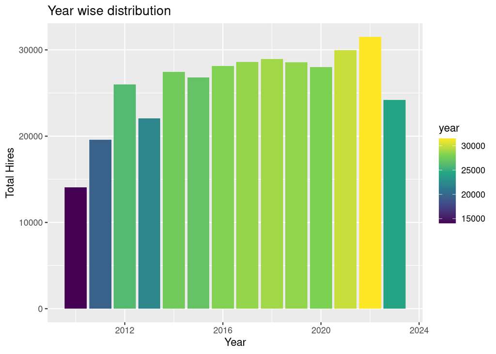

```r
#Year Wise Distribution of rental bikes from 2010-2023
ggplot(bikes, aes(x = year, y = Hires)) + geom_bar(stat = "summary", fun = "mean", aes(fill=..y..))+
  scale_fill_viridis_c() +
  labs(title = 'Year wise distribution',
         x = "Year",
         y = "Total Hires",
         fill = "year")
```

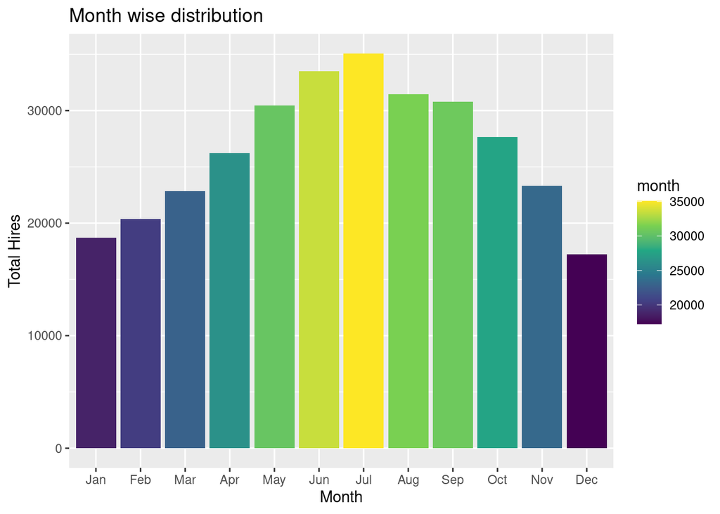

```r
#Month Wise Distribution of rental bikes from 2010-2023
ggplot(bikes, aes(x = factor(month, levels = c("Jan", "Feb", "Mar", "Apr", "May", "Jun", "Jul", "Aug", "Sep", "Oct", "Nov", "Dec")), y = Hires)) + geom_histogram(aes(fill=..y..),stat = "summary", fun = "mean") + scale_fill_discrete(breaks = c("Jan", "Feb", "Mar", "Apr", "May", "Jun", "Jul", "Aug", "Sep", "Oct", "Nov", "Dec"))+
  scale_fill_viridis_c() +
  labs(title = 'Month wise distribution',
         x = "Month",
         y = "Total Hires",
         fill = "month")
```

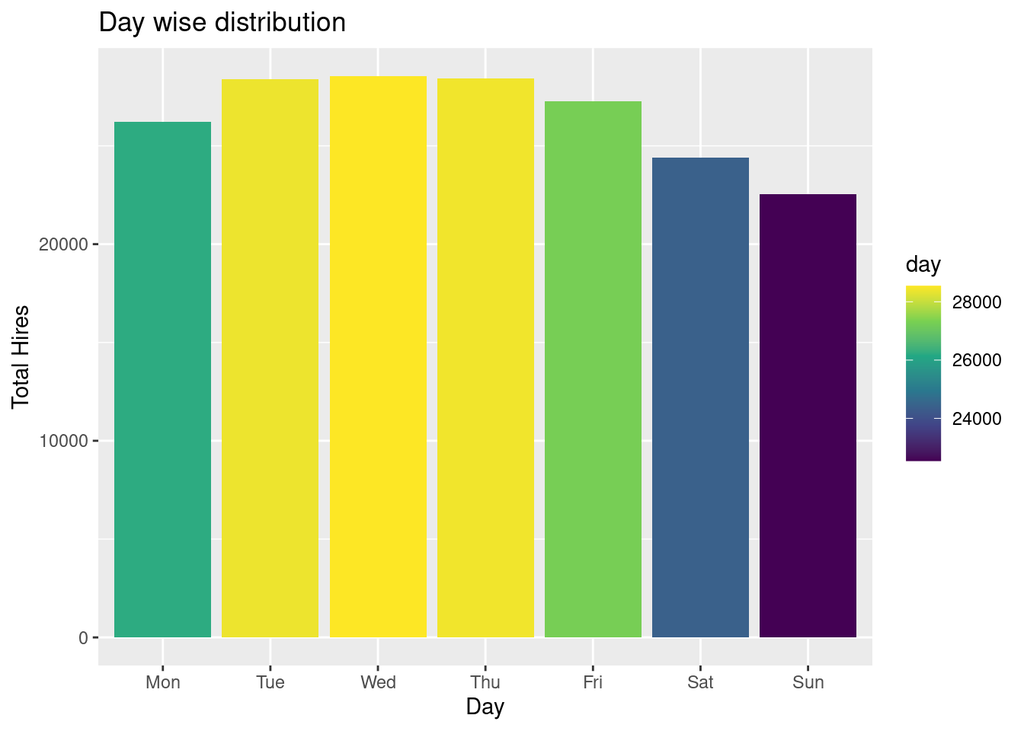

```r
#Day Wise Distribution of rental bikes from 2010-2023
ggplot(bikes, aes(x = factor(day, levels = c("Mon", "Tue", "Wed", "Thu", "Fri", "Sat", "Sun")), y = Hires)) + geom_bar(stat = "summary", fun = "mean", aes(fill=..y..))+
  scale_fill_discrete(breaks = c("Mon", "Tue", "Wed", "Thu", "Fri", "Sat", "Sun"))+
  scale_fill_viridis_c() +
    labs(title = 'Day wise distribution',
         x = "Day",
         y = "Total Hires",
         fill = "day")
```

### Linear Model Analysis w.r.t. day, month, & year

```r
#LM hires w.r.t. day, month, year.
m.hires.m <- lm(Hires ~ month, data = bikes)
( m.hires.m.emm <- emmeans(m.hires.m, ~ month) )
```

```
##  month emmean  SE   df lower.CL upper.CL
##  Apr    26242 387 4789    25482    27002
##  Aug    31448 368 4789    30726    32170
##  Dec    17236 381 4789    16490    17983
##  Feb    20370 399 4789    19587    21153
##  Jan    18701 381 4789    17953    19448
##  Jul    35067 381 4789    34320    35813
##  Jun    33503 389 4789    32741    34266
##  Mar    22851 381 4789    22104    23599
##  May    30452 383 4789    29702    31202
##  Nov    23322 387 4789    22562    24082
##  Oct    27667 381 4789    26920    28415
##  Sep    30794 374 4789    30061    31528
##
## Confidence level used: 0.95
```

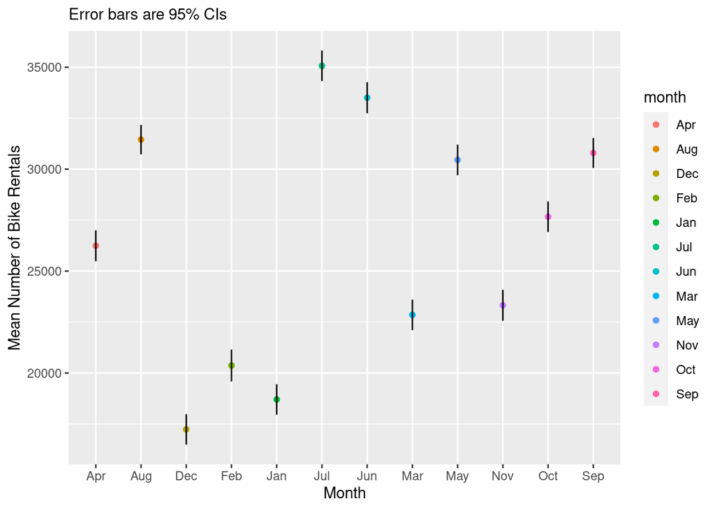

```r
#Visual representation of the estimated mean number of bike rentals for each month, along with the associated uncertainty captured by the 95% confidence intervals
ggplot(summary(m.hires.m.emm), aes(x=month, y=emmean, ymin=lower.CL, ymax=upper.CL)) + geom_point(aes(color=month) )+ geom_linerange() + labs(x="Month", y="Mean Number of Bike Rentals", subtitle="Error bars are 95% CIs")
```

### ANOVA Analysis

```r
# ANOVA or t-tests for differences across years, months, and days
# ANOVA by year
year_anova <- aov(Hires ~ year, data = bikes)
summary(year_anova)
```

```
##               Df    Sum Sq   Mean Sq F value Pr(>F)
## year           1 3.370e+10 3.370e+10   401.6 <2e-16 ***
## Residuals   4799 4.027e+11 8.392e+07
## ---
## Signif. codes:  0 '***' 0.001 '**' 0.01 '*' 0.05 '.' 0.1 ' ' 1
```

```r
# ANOVA by month
month_anova <- aov(Hires ~ month, data = bikes)
summary(month_anova)
```

```
##               Df    Sum Sq   Mean Sq F value Pr(>F)
## month         11 1.560e+11 1.418e+10   242.2 <2e-16 ***
## Residuals   4789 2.804e+11 5.856e+07
## ---
## Signif. codes:  0 '***' 0.001 '**' 0.01 '*' 0.05 '.' 0.1 ' ' 1
```

```r
# ANOVA by day
day_anova <- aov(Hires ~ day, data = bikes)
summary(day_anova)
```

```
##               Df    Sum Sq   Mean Sq F value Pr(>F)
## day            6 2.198e+10 3.664e+09   42.38 <2e-16 ***
## Residuals   4794 4.144e+11 8.645e+07
## ---
## Signif. codes:  0 '***' 0.001 '**' 0.01 '*' 0.05 '.' 0.1 ' ' 1
```

```r
# Regression with year, month, and day variables
full_model <- lm(Hires ~ wfh + rule_of_6_indoors + eat_out_to_help_out + factor(year) + month + day, data = bikes)
summary(full_model)
```

```
##
## Call:
## lm(formula = Hires ~ wfh + rule_of_6_indoors + eat_out_to_help_out +
##     factor(year) + month + day, data = bikes)
##
## Residuals:
##    Min     1Q Median     3Q    Max
## -26009  -3447    613   3714  34074
##
## Coefficients:
##                      Estimate Std. Error t value Pr(>|t|)
## (Intercept)           14675.1      639.7  22.942  < 2e-16 ***
## wfh1                  -5847.8      516.8 -11.315  < 2e-16 ***
## rule_of_6_indoors1     3283.1      713.2   4.603 4.27e-06 ***
## eat_out_to_help_out1   -179.3     1291.3  -0.139 0.889583
## factor(year)2011       5457.0      598.6   9.117  < 2e-16 ***
## factor(year)2012      11921.5      598.4  19.923  < 2e-16 ***
## factor(year)2013       7920.0      598.6  13.232  < 2e-16 ***
## factor(year)2014      13340.1      598.6  22.287  < 2e-16 ***
## factor(year)2015      12742.7      599.1  21.271  < 2e-16 ***
## factor(year)2016      14056.4      598.4  23.491  < 2e-16 ***
## factor(year)2017      14513.1      598.6  24.246  < 2e-16 ***
## factor(year)2018      14835.9      598.6  24.786  < 2e-16 ***
## factor(year)2019      14439.2      598.6  24.123  < 2e-16 ***
## factor(year)2020      17409.4      694.3  25.073  < 2e-16 ***
## factor(year)2021      18786.1      663.8  28.301  < 2e-16 ***
## factor(year)2022      23289.7      781.6  29.796  < 2e-16 ***
## factor(year)2023      14763.4      808.8  18.253  < 2e-16 ***
## monthAug               5240.2      442.2  11.850  < 2e-16 ***
## monthDec              -8536.7      439.2 -19.435  < 2e-16 ***
## monthFeb              -6354.4      448.7 -14.162  < 2e-16 ***
## monthJan              -7995.3      438.2 -18.244  < 2e-16 ***
## monthJul               8569.2      438.0  19.566  < 2e-16 ***
## monthJun               6978.5      444.4  15.704  < 2e-16 ***
## monthMar              -3664.6      436.9  -8.387  < 2e-16 ***
## monthMay               4036.0      438.1   9.212  < 2e-16 ***
## monthNov              -2719.9      444.6  -6.117 1.03e-09 ***
## monthOct               1532.0      442.6   3.461 0.000542 ***
## monthSep               4576.3      441.2  10.371  < 2e-16 ***
## dayMon                -1071.8      331.5  -3.233 0.001234 **
## daySat                -2847.9      331.9  -8.581  < 2e-16 ***
## daySun                -4733.5      331.8 -14.267  < 2e-16 ***
## dayThu                 1179.8      331.8   3.556 0.000380 ***
## dayTue                 1134.2      331.7   3.420 0.000632 ***
## dayWed                 1250.1      331.5   3.771 0.000165 ***
## ---
## Signif. codes:  0 '***' 0.001 '**' 0.01 '*' 0.05 '.' 0.1 ' ' 1
##
## Residual standard error: 6144 on 4767 degrees of freedom
## Multiple R-squared:  0.5876, Adjusted R-squared:  0.5848
## F-statistic: 205.9 on 33 and 4767 DF,  p-value: < 2.2e-16
```

**Explanation**

**Month-wise Distribution:** Month significantly influences bike hires (F(11, 4789) = 242.2, p < 2e-16). Considerable variability in bike hires is associated with different months.

**Day-wise Distribution:** Day of the week affects bike hires (F(6, 4794) = 42.38, p < 2e-16). Notable variability in bike hires is linked to different days of the week.

```r
# LM with respect to DMY.

#LM
m.wfh.dmy <- lm(Hires ~ wfh + day + month + factor(year), data = bikes)
( m.wfh.dmy.emm <- emmeans(m.wfh.dmy, ~ wfh) )
```

```
##  wfh emmean  SE   df lower.CL upper.CL
##  0    27117 146 4769    26830    27403
##  1    21853 384 4769    21101    22606
##
## Results are averaged over the levels of: day, month, year
## Confidence level used: 0.95
```

```r
(  m.wfh.dmy.contrast <- confint(pairs(m.wfh.dmy.emm))  )
```

```
##  contrast    estimate  SE   df lower.CL upper.CL
##  wfh0 - wfh1     5263 487 4769     4310     6217
##
## Results are averaged over the levels of: day, month, year
## Confidence level used: 0.95
```

```r
m.rule.dmy <- lm(Hires ~ rule_of_6_indoors + day + month + factor(year), data = bikes)
( m.rule.dmy.emm <- emmeans(m.rule.dmy, ~ rule_of_6_indoors) )
```

```
##  rule_of_6_indoors emmean    SE   df lower.CL upper.CL
##  0                  25863  93.5 4769    25679    26046
##  1                  27104 693.8 4769    25743    28464
##
## Results are averaged over the levels of: day, month, year
## Confidence level used: 0.95
```

```r
(  m.rule.dmy.contrast <- confint(pairs(m.rule.dmy.emm))  )
```

```
##  contrast                                estimate  SE   df lower.CL upper.CL
##  rule_of_6_indoors0 - rule_of_6_indoors1    -1241 701 4769    -2615      133
##
## Results are averaged over the levels of: day, month, year
## Confidence level used: 0.95
```

```r
m.eat.dmy <- lm(Hires ~ eat_out_to_help_out + day + month + factor(year), data = bikes)
( m.eat.dmy.emm <- emmeans(m.eat.dmy, ~ eat_out_to_help_out) )
```

```
##  eat_out_to_help_out emmean     SE   df lower.CL upper.CL
##  0                    25870   92.7 4769    25689    26052
##  1                    29175 1264.5 4769    26696    31654
##
## Results are averaged over the levels of: day, month, year
## Confidence level used: 0.95
```

```r
(  m.eat.dmy.contrast <- confint(pairs(m.eat.dmy.emm))  )
```

```
##  contrast                                    estimate   SE   df lower.CL upper.CL
##  eat_out_to_help_out0 - eat_out_to_help_out1    -3305 1267 4769    -5789     -820
##
## Results are averaged over the levels of: day, month, year
## Confidence level used: 0.95
```

```r
# Compare models using ANOVA or other model comparison techniques
anova(m.wfh.eat.rule_2, full_model)
```

```
## Analysis of Variance Table
##
## Model 1: Hires ~ wfh + rule_of_6_indoors + eat_out_to_help_out
## Model 2: Hires ~ wfh + rule_of_6_indoors + eat_out_to_help_out + factor(year) +
##     month + day
##   Res.Df        RSS Df  Sum of Sq      F    Pr(>F)
## 1   4797 4.2454e+11
## 2   4767 1.7997e+11 30 2.4458e+11 215.95 < 2.2e-16 ***
## ---
## Signif. codes:  0 '***' 0.001 '**' 0.01 '*' 0.05 '.' 0.1 ' ' 1
```

**Explanation for ANOVA** Two models are being compared:

Model 1 looks at how work-from-home, rule of 6, and Eat Out to Help Out affect the number of hires. Model 2 adds year, month, and day to the mix to see if they also play a role. Key Findings:

Model 2 is significantly better at explaining the variation in hires. This means that year, month, and day have a meaningful impact on the number of hires, beyond the other factors. The F-test and p-value strongly support this conclusion (p-value(2.2e-16) is very small, indicating a very low chance of getting these results by random chance).

### Summary Report: Control for Differences

The analysis appropriately controls for potential differences between different years, months, and days of the week.

Year-wise Distribution: The variable “year” significantly influences bike hires (F(1, 4799) = 401.6, p < 2e-16). This indicates that the model accounts for variations in bike hires attributed to the year variable.

Month-wise Distribution: The month significantly influences bike hires (F(11, 4789) = 242.2, p < 2e-16). The model recognizes considerable variability associated with different months.

Day-wise Distribution: The day of the week affects bike hires (F(6, 4794) = 42.38, p < 2e-16). The model acknowledges notable variability linked to different days of the week.

```
                                             *END*
```